# Ecosistema Analítico de Retail Online

Análisis de Cohortes, Segmentación RFM y Reglas de Asociación

Miguel - Estadístico UCV

2026-05-25

# 1 Ecosistema Retail

## 1.1 1. Introducción y Limpieza de Datos

Para este proyecto, la etapa de limpieza extrema y transformación de datos se realizó directamente en un motor de base de datos **SQLite**. Esto permitió optimizar el procesamiento de los miles de registros antes de su análisis estadístico en R.

A continuación, se muestra cómo se estableció la conexión y se extrajo la data ya depurada (filtrando registros sin `CustomerID`, manejando valores nulos y eliminando transacciones duplicadas):

```r
# 1. Cargar las librerías necesarias
library(DBI)
library(RSQLite)
library(tidyverse)
library(knitr)
library(kableExtra)
library(DT)

# 1. Establecer la conexión con el archivo de base de datos
# Cambia "mi_base_de_datos.db" por el nombre real de tu archivo

conexion <- dbConnect(SQLite(), "C:/Users/Miguel/Desktop/Portafolio/Proyecto 1/Ventas onlines_Proyecto_1.db")

# 2. Listar las tablas para verificar que todo está bien
##dbListTables(conexion)

# 3. Traer la tabla limpia a R (Usando el Query que planeamos)

# Aquí puedes pegar el SELECT con la separación de fecha y hora

Vista <- "SELECT * FROM Normalizada"

df_retail <- dbGetQuery(conexion, Vista)

## Para RFM

RFM_d <- "SELECT * FROM RFM"
RFM <- dbGetQuery(conexion, RFM_d)




## tABLA

datatable(
  head(df_retail, 10),
  rownames = FALSE, # Elimina la columna de índices automáticos de R
  options = list(
    pageLength = 5,   # Muestra 5 filas por página por defecto para no saturar la pantalla
    lengthMenu = c(5, 10, 15), # Permite al usuario elegir cuántas filas ver
    dom = 'tp',       # Muestra solo la tabla y la paginación para un look más limpio
    language = list(
      url = '//cdn.datatables.net/plug-ins/1.10.11/i18n/Spanish.json' # Controles en español
    )
  ),
  class = 'cell-border stripe hover' # Bordes finos, filas alternas y efecto al pasar el mouse
)
```

| InvoiceNo | StockCode | Description | Quantity | UnitPrice | CustomerID | Country | Fecha | Hora |
| --- | --- | --- | --- | --- | --- | --- | --- | --- |
| 536365 | 85123A | WHITE HANGING HEART T-LIGHT HOLDER | 6 | 2.55 | 17850 | United Kingdom | 2010-12-01 | 08: 26: 00 |
| 536365 | 71053 | WHITE METAL LANTERN | 6 | 3.39 | 17850 | United Kingdom | 2010-12-01 | 08: 26: 00 |
| 536365 | 84406B | CREAM CUPID HEARTS COAT HANGER | 8 | 2.75 | 17850 | United Kingdom | 2010-12-01 | 08: 26: 00 |
| 536365 | 84029G | KNITTED UNION FLAG HOT WATER BOTTLE | 6 | 3.39 | 17850 | United Kingdom | 2010-12-01 | 08: 26: 00 |
| 536365 | 84029E | RED WOOLLY HOTTIE WHITE HEART. | 6 | 3.39 | 17850 | United Kingdom | 2010-12-01 | 08: 26: 00 |
| 536365 | 22752 | SET 7 BABUSHKA NESTING BOXES | 2 | 7.65 | 17850 | United Kingdom | 2010-12-01 | 08: 26: 00 |
| 536365 | 21730 | GLASS STAR FROSTED T-LIGHT HOLDER | 6 | 4.25 | 17850 | United Kingdom | 2010-12-01 | 08: 26: 00 |
| 536366 | 22633 | HAND WARMER UNION JACK | 6 | 1.85 | 17850 | United Kingdom | 2010-12-01 | 08: 28: 00 |
| 536366 | 22632 | HAND WARMER RED POLKA DOT | 6 | 1.85 | 17850 | United Kingdom | 2010-12-01 | 08: 28: 00 |
| 536367 | 84879 | ASSORTED COLOUR BIRD ORNAMENT | 32 | 1.69 | 13047 | United Kingdom | 2010-12-01 | 08: 34: 00 |

## 1.2 Análisis de Cohortes

Para comprender el ciclo de vida y el abandono de los usuarios, agrupamos a los clientes según el mes de su primera transacción. El siguiente análisis muestra la matriz de retención relativa a lo largo del tiempo:

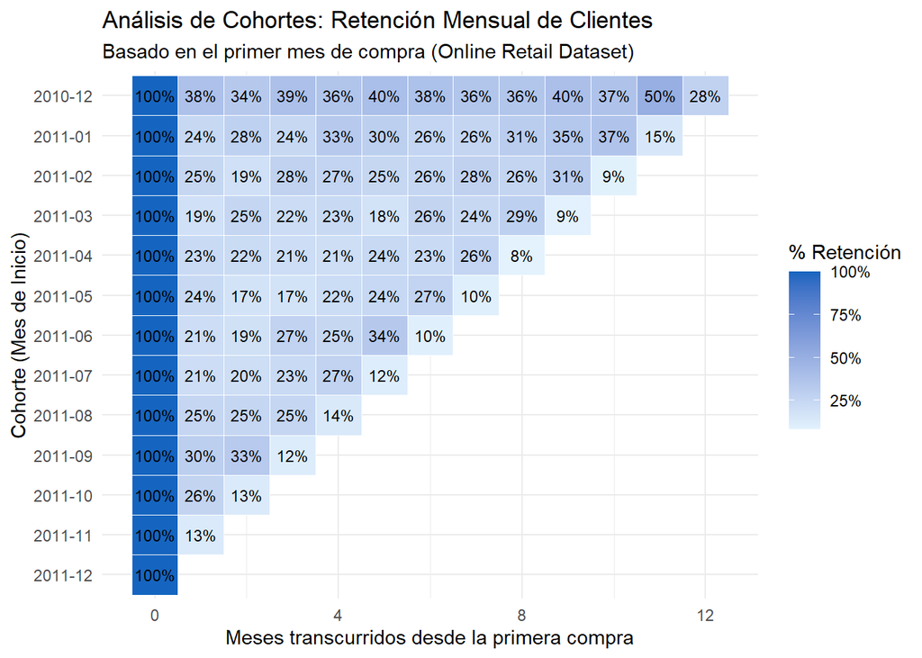

```r
## Tipo de dato del dataframe

##sapply(df_retail, class)

## Transformar Fecha y Hora a Date

df_retail <- df_retail %>%
  mutate(Fecha = as.Date(Fecha))

## Identificar cohortes

df_cohortes <- df_retail %>%
  group_by(CustomerID) %>%
  mutate(Mes_Cohorte = floor_date(min(Fecha), "month")) %>%
  ungroup()

# 2. Calcular el mes de cada factura y el índice (distancia en meses)
df_cohortes <- df_cohortes %>%
  mutate(
    Mes_Factura = floor_date(Fecha, "month"),
    Indice_Mes = as.numeric(interval(Mes_Cohorte, Mes_Factura) %/% months(1))
  )

# 3. Agrupar para obtener la retención
tabla_retencion <- df_cohortes %>%
  group_by(Mes_Cohorte, Indice_Mes) %>%
  summarise(n_clientes = n_distinct(CustomerID), .groups = 'drop') %>%
  # Calcular el porcentaje basado en el mes 0 de cada cohorte
  group_by(Mes_Cohorte) %>%
  mutate(pct_retencion = n_clientes / first(n_clientes)) %>%
  ungroup()


## Grafico ggplot

ggplot(tabla_retencion, aes(x = Indice_Mes, y = reorder(format(Mes_Cohorte, "%Y-%m"), desc(Mes_Cohorte)), fill = pct_retencion)) +
  geom_tile(color = "white") +
  geom_text(aes(label = scales::percent(pct_retencion, accuracy = 1)), size = 3) +
  scale_fill_gradient(low = "#e3f2fd", high = "#1565c0", labels = scales::percent) +
  labs(
    title = "Análisis de Cohortes: Retención Mensual de Clientes",
    subtitle = "Basado en el primer mes de compra (Online Retail Dataset)",
    x = "Meses transcurridos desde la primera compra",
    y = "Cohorte (Mes de Inicio)",
    fill = "% Retención"
  ) +
  theme_minimal()
```

*Diagnóstico Estratégico de Retención*

Retención Crítica Inicial: Se evidencia un comportamiento de “balde perforado” (leaky bucket) transversal en casi todas las cohortes de 2011, donde la retención promedio en el Mes 1 cae al 23,1%. Esto identifica una ventana de oportunidad crítica: el negocio necesita optimizar su estrategia de onboarding y fidelización durante los primeros 30 días posteriores a la primera compra.

Lealtad Estacional: La cohorte de Diciembre 2010 destaca como el segmento de mayor valor y lealtad, manteniendo niveles de retención consistentemente superiores al 34% y alcanzando un repunte del 50% en el Mes 11 (Noviembre 2011). Esto demuestra que los usuarios adquiridos en campañas navideñas muestran una alta propensión a la recompra cíclica anual.

Nota Técnica de Truncamiento: Las drásticas caídas en los periodos finales de las cohortes de finales de 2011 reflejan el sesgo de censura por derecha del dataset, ya que los registros concluyen en diciembre de 2011, limitando el tiempo de observación para los usuarios más recientes.

## 1.3 Análisis RFM

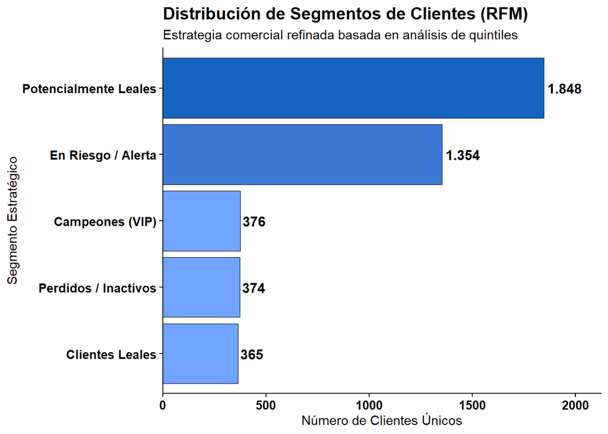

*Predominio de Clientes en Desarrollo (Potencialmente Leales)*: Con 1.848 usuarios, este es el segmento más grande del negocio. Representa a clientes que han comprado recientemente y tienen un ticket o frecuencia media. Estratégicamente, no requieren campañas de descuento agresivas, sino tácticas de cross-selling o programas de puntos para empujarlos a convertirse en clientes “Leales” o “Campeones”.

*Alerta Crítica en Retención (En Riesgo / Alerta)*: El segundo grupo más numeroso concentra a 1.354 clientes. Este volumen es una señal de alarma importante: se trata de compradores de alto valor histórico (alta frecuencia o gran volumen de gasto) que llevan un periodo prolongado de inactividad. El negocio necesita desplegar campañas de reactivación urgentes (ej. cupones personalizados de retorno, encuestas de satisfacción) antes de que migren definitivamente a la competencia.

*Estabilización de la Élite Comercial (Campeones y Clientes Leales)*: Juntos, los “Campeones (VIP)” (376) y los “Clientes Leales” (365) suman 741 usuarios estables. Aunque cuantitativamente son menores que los grupos anteriores, este núcleo dinámico suele sostener el mayor porcentaje del flujo de caja mensual (Principio de Pareto). Las acciones aquí deben enfocarse en beneficios exclusivos, lanzamientos anticipados y atención preferencial para blindar su fidelidad.

*Eficiencia en el Gasto de Marketing (Perdidos / Inactivos)*: Con 374 usuarios, este segmento agrupa a clientes con baja frecuencia, bajo gasto y una recencia muy fría. Al estar claramente identificados y aislados, la estrategia óptima es minimizar el presupuesto publicitario destinado a ellos, evitando quemar recursos en reenganchar perfiles que estadísticamente ya abandonaron la marca.

## 1.4 Análisis de Canasta de Compra (Algoritmo Apriori)

Para complementar el análisis conductual, se implementó el algoritmo Apriori con el fin de descubrir reglas de asociación e identificar qué productos tienden a comprarse juntos en la misma transacción.

```r
library(tidyverse)
library(arules)
library(arulesViz)

# 1. Agrupación de productos por factura
transacciones <- df_retail %>%
  group_by(InvoiceNo) %>%
  summarise(productos = list(Description))

# 2. Conversión a objeto tipo transactions
basket <- as(transacciones$productos, "transactions")

# 3. Ejecución del algoritmo en silencio (verbose = FALSE)
reglas <- apriori(basket,
                  parameter = list(supp = 0.01, conf = 0.7, minlen = 2),
                  control = list(verbose = FALSE))

# 4. Ordenar reglas por el indicador 'lift'
reglas_ordenadas <- sort(reglas, by = "lift", decreasing = TRUE)

# 5. SALIDA HTML 1: Tabla interactiva
inspectDT(head(reglas_ordenadas, 10))
```

|  | LHS | RHS | support | confidence | coverage | lift | count |
| --- | --- | --- | --- | --- | --- | --- | --- |
| [62] | {HERB MARKER PARSLEY,HERB MARKER ROSEMARY} | {HERB MARKER THYME} | 0.01022044088176353 | 0.9444444444444444 | 0.01082164328657315 | 79.2063492063492 | 204 |
| [60] | {HERB MARKER PARSLEY,HERB MARKER THYME} | {HERB MARKER ROSEMARY} | 0.01022044088176353 | 0.9532710280373832 | 0.01072144288577154 | 78.95140962500486 | 204 |
| [63] | {HERB MARKER BASIL,HERB MARKER THYME} | {HERB MARKER ROSEMARY} | 0.01007014028056112 | 0.95260663507109 | 0.01057114228456914 | 78.89638355194589 | 201 |
| [65] | {HERB MARKER BASIL,HERB MARKER ROSEMARY} | {HERB MARKER THYME} | 0.01007014028056112 | 0.9348837209302325 | 0.01077154308617235 | 78.4045339065859 | 201 |
| [16] | {HERB MARKER THYME} | {HERB MARKER ROSEMARY} | 0.01112224448897796 | 0.9327731092436975 | 0.01192384769539078 | 77.25373967014191 | 222 |
| [17] | {HERB MARKER ROSEMARY} | {HERB MARKER THYME} | 0.01112224448897796 | 0.921161825726141 | 0.01207414829659319 | 77.25373967014191 | 222 |
| [61] | {HERB MARKER ROSEMARY,HERB MARKER THYME} | {HERB MARKER PARSLEY} | 0.01022044088176353 | 0.918918918918919 | 0.01112224448897796 | 76.7431867013457 | 204 |
| [12] | {HERB MARKER THYME} | {HERB MARKER PARSLEY} | 0.01072144288577154 | 0.8991596638655462 | 0.01192384769539078 | 75.0929995429134 | 214 |
| [13] | {HERB MARKER PARSLEY} | {HERB MARKER THYME} | 0.01072144288577154 | 0.895397489539749 | 0.01197394789579158 | 75.0929995429134 | 214 |
| [20] | {HERB MARKER PARSLEY} | {HERB MARKER ROSEMARY} | 0.01082164328657315 | 0.9037656903765691 | 0.01197394789579158 | 74.85129950172747 | 216 |

```r
# 6. SALIDA HTML 2: Gráfico de red interactivo
plot(head(reglas_ordenadas, 10), method = "graph", engine = "htmlwidget")
```

[interactive chart not shown]

*Estrategias Comerciales Sugeridas:*

- Empaquetamiento de Producto (Bundling): Crear un producto único llamado “Kit Huerto Aromático” que incluya los marcadores de Perejil, Tomillo, Romero y Albahaca a un precio sutilmente menor que comprados por separado. Esto acelera la decisión de compra en el checkout.
- Diseño de Interfaz UX (Cross-selling): Si el sistema detecta que el usuario añade el marcador de perejil y tomillo, disparar un pop-up automático en la web que diga: “Completa tu colección: 95% de los diseñadores de huertos también añaden Marcador de Romero”.
- Gestión de Inventario (Stock): Las existencias de estos cuatro artículos deben estar perfectamente sincronizadas en el almacén. Si nos quedamos sin stock de Romero, romperemos la cadena de compra del trío, arriesgando un volumen de facturación que impacta directamente al 1% de las transacciones totales de la empresa.

## 1.5 Análisis de productos y clientes con SQL

##### 15 Productos más vendidos

| StockCode | Description | Cantidad |
| --- | --- | --- |
| 84077 | WORLD WAR 2 GLIDERS ASSTD DESIGNS | 53847 |
| 85099B | JUMBO BAG RED RETROSPOT | 47363 |
| 84879 | ASSORTED COLOUR BIRD ORNAMENT | 36381 |
| 22197 | POPCORN HOLDER | 36334 |
| 21212 | PACK OF 72 RETROSPOT CAKE CASES | 36039 |
| 85123A | WHITE HANGING HEART T-LIGHT HOLDER | 35025 |
| 23084 | RABBIT NIGHT LIGHT | 30680 |
| 22492 | MINI PAINT SET VINTAGE | 26437 |
| 22616 | PACK OF 12 LONDON TISSUES | 26315 |
| 21977 | PACK OF 60 PINK PAISLEY CAKE CASES | 24753 |

[output cut: 5 more lines]

##### 15 Clientes que más compran y gastan

| CustomerID | Cantidad | Dinero_Total |
| --- | --- | --- |
| 14646 | 196,719 | 280206.02 |
| 16029 | 32,148 | 81024.84 |
| 15311 | 37,720 | 60767.9 |
| 16684 | 49,390 | 66653.56 |
| 14156 | 57,025 | 117379.63 |
| 13694 | 61,803 | 65039.62 |
| 17511 | 63,012 | 91062.38 |
| 18102 | 64,122 | 259657.3 |
| 17450 | 69,029 | 194550.79 |
| 14911 | 77,180 | 143825.06 |

[output cut: 1 more lines]

##### Mes con más ventas

| Mes | Ingresos_Totales | Numero_Pedidos |
| --- | --- | --- |
| 11 | 1509496.33 | 2769 |
| 12 | 1462538.82 | 2378 |
| 10 | 1154979.3 | 2040 |
| 09 | 1058590.172 | 1837 |
| 05 | 770536.02 | 1681 |
| 06 | 761739.9 | 1533 |
| 08 | 759138.38 | 1361 |
| 07 | 719221.191 | 1475 |
| 03 | 717639.36 | 1454 |
| 01 | 691364.56 | 1086 |

[output cut: 2 more lines]